# Homework1

## Homework 1

```r
library(dplyr)
library(ggplot2)
library(tidyr)
library(lubridate)
library(maps)
```

Part 1

```r
PM_2002 <- read.csv("~/Desktop/PM566labs/2002_PM.csv")
```

```r
PM_2022 <- read.csv("~/Desktop/PM566labs/2022_PM.csv")
```

```r
## Summary of 2002 Data
dim(PM_2002)
```

```
[1] 15976    22
```

```r
head(PM_2002)
```

```
        Date Source  Site.ID POC Daily.Mean.PM2.5.Concentration    Units
1 01/05/2002    AQS 60010007   1                           25.1 ug/m3 LC
2 01/06/2002    AQS 60010007   1                           31.6 ug/m3 LC
3 01/08/2002    AQS 60010007   1                           21.4 ug/m3 LC
4 01/11/2002    AQS 60010007   1                           25.9 ug/m3 LC
5 01/14/2002    AQS 60010007   1                           34.5 ug/m3 LC
6 01/17/2002    AQS 60010007   1                           41.0 ug/m3 LC
  Daily.AQI.Value Local.Site.Name Daily.Obs.Count Percent.Complete
1              81       Livermore               1              100
2              93       Livermore               1              100
3              74       Livermore               1              100
4              82       Livermore               1              100
5              98       Livermore               1              100
6             115       Livermore               1              100
  AQS.Parameter.Code AQS.Parameter.Description Method.Code
```

[output cut: 27 more lines]

```r
tail(PM_2002)
```

```
            Date Source  Site.ID POC Daily.Mean.PM2.5.Concentration    Units
15971 12/10/2002    AQS 61131003   1                             15 ug/m3 LC
15972 12/13/2002    AQS 61131003   1                             15 ug/m3 LC
15973 12/22/2002    AQS 61131003   1                              1 ug/m3 LC
15974 12/25/2002    AQS 61131003   1                             23 ug/m3 LC
15975 12/28/2002    AQS 61131003   1                              5 ug/m3 LC
15976 12/31/2002    AQS 61131003   1                              6 ug/m3 LC
      Daily.AQI.Value      Local.Site.Name Daily.Obs.Count Percent.Complete
15971              62 Woodland-Gibson Road               1              100
15972              62 Woodland-Gibson Road               1              100
15973               6 Woodland-Gibson Road               1              100
15974              77 Woodland-Gibson Road               1              100
15975              28 Woodland-Gibson Road               1              100
15976              33 Woodland-Gibson Road               1              100
      AQS.Parameter.Code AQS.Parameter.Description Method.Code
```

[output cut: 27 more lines]

```r
names(PM_2002)
```

```
 [1] "Date"                           "Source"
 [3] "Site.ID"                        "POC"
 [5] "Daily.Mean.PM2.5.Concentration" "Units"
 [7] "Daily.AQI.Value"                "Local.Site.Name"
 [9] "Daily.Obs.Count"                "Percent.Complete"
[11] "AQS.Parameter.Code"             "AQS.Parameter.Description"
[13] "Method.Code"                    "Method.Description"
[15] "CBSA.Code"                      "CBSA.Name"
[17] "State.FIPS.Code"                "State"
[19] "County.FIPS.Code"               "County"
[21] "Site.Latitude"                  "Site.Longitude"
```

```r
str(PM_2002)
```

```
'data.frame':   15976 obs. of  22 variables:
 $ Date                          : chr  "01/05/2002" "01/06/2002" "01/08/2002" "01/11/2002" ...
 $ Source                        : chr  "AQS" "AQS" "AQS" "AQS" ...
 $ Site.ID                       : int  60010007 60010007 60010007 60010007 60010007 60010007 60010007 60010007 60010007 60010007 ...
 $ POC                           : int  1 1 1 1 1 1 1 1 1 1 ...
 $ Daily.Mean.PM2.5.Concentration: num  25.1 31.6 21.4 25.9 34.5 41 29.3 15 18.8 37.9 ...
 $ Units                         : chr  "ug/m3 LC" "ug/m3 LC" "ug/m3 LC" "ug/m3 LC" ...
 $ Daily.AQI.Value               : int  81 93 74 82 98 115 89 62 69 107 ...
 $ Local.Site.Name               : chr  "Livermore" "Livermore" "Livermore" "Livermore" ...
 $ Daily.Obs.Count               : int  1 1 1 1 1 1 1 1 1 1 ...
 $ Percent.Complete              : num  100 100 100 100 100 100 100 100 100 100 ...
 $ AQS.Parameter.Code            : int  88101 88101 88101 88101 88101 88101 88101 88101 88101 88101 ...
 $ AQS.Parameter.Description     : chr  "PM2.5 - Local Conditions" "PM2.5 - Local Conditions" "PM2.5 - Local Conditions" "PM2.5 - Local Conditions" ...
 $ Method.Code                   : int  120 120 120 120 120 120 120 120 120 120 ...
 $ Method.Description            : chr  "Andersen RAAS2.5-300 PM2.5 SEQ w/WINS" "Andersen RAAS2.5-300 PM2.5 SEQ w/WINS" "Andersen RAAS2.5-300 PM2.5 SEQ w/WINS" "Andersen RAAS2.5-300 PM2.5 SEQ w/WINS" ...
 $ CBSA.Code                     : int  41860 41860 41860 41860 41860 41860 41860 41860 41860 41860 ...
 $ CBSA.Name                     : chr  "San Francisco-Oakland-Hayward, CA" "San Francisco-Oakland-Hayward, CA" "San Francisco-Oakland-Hayward, CA" "San Francisco-Oakland-Hayward, CA" ...
 $ State.FIPS.Code               : int  6 6 6 6 6 6 6 6 6 6 ...
 $ State                         : chr  "California" "California" "California" "California" ...
 $ County.FIPS.Code              : int  1 1 1 1 1 1 1 1 1 1 ...
 $ County                        : chr  "Alameda" "Alameda" "Alameda" "Alameda" ...
 $ Site.Latitude                 : num  37.7 37.7 37.7 37.7 37.7 ...
 $ Site.Longitude                : num  -122 -122 -122 -122 -122 ...
```

2002 Data Set:

There are 15,976 rows and 22 Columns. The different columns name include Dates, Source, Site.ID, Country, Site Longitude to name some examples. The “head” function gives us the first 6 rows with the earliest date being 1/05/2002 and the last 6 rows with the date being 12/31/2002.

```r
# Summary of 2022 Data
dim(PM_2022)
```

```
[1] 59918    22
```

```r
head(PM_2022)
```

```
        Date Source  Site.ID POC Daily.Mean.PM2.5.Concentration    Units
1 01/01/2022    AQS 60010007   3                           12.7 ug/m3 LC
2 01/02/2022    AQS 60010007   3                           13.9 ug/m3 LC
3 01/03/2022    AQS 60010007   3                            7.1 ug/m3 LC
4 01/04/2022    AQS 60010007   3                            3.7 ug/m3 LC
5 01/05/2022    AQS 60010007   3                            4.2 ug/m3 LC
6 01/06/2022    AQS 60010007   3                            3.8 ug/m3 LC
  Daily.AQI.Value Local.Site.Name Daily.Obs.Count Percent.Complete
1              58       Livermore               1              100
2              60       Livermore               1              100
3              39       Livermore               1              100
4              21       Livermore               1              100
5              23       Livermore               1              100
6              21       Livermore               1              100
  AQS.Parameter.Code AQS.Parameter.Description Method.Code
```

[output cut: 27 more lines]

```r
tail(PM_2022)
```

```
            Date Source  Site.ID POC Daily.Mean.PM2.5.Concentration    Units
59913 12/01/2022    AQS 61131003   1                            3.4 ug/m3 LC
59914 12/07/2022    AQS 61131003   1                            3.8 ug/m3 LC
59915 12/13/2022    AQS 61131003   1                            6.0 ug/m3 LC
59916 12/19/2022    AQS 61131003   1                           34.8 ug/m3 LC
59917 12/25/2022    AQS 61131003   1                           23.2 ug/m3 LC
59918 12/31/2022    AQS 61131003   1                            1.0 ug/m3 LC
      Daily.AQI.Value      Local.Site.Name Daily.Obs.Count Percent.Complete
59913              19 Woodland-Gibson Road               1              100
59914              21 Woodland-Gibson Road               1              100
59915              33 Woodland-Gibson Road               1              100
59916              99 Woodland-Gibson Road               1              100
59917              77 Woodland-Gibson Road               1              100
59918               6 Woodland-Gibson Road               1              100
      AQS.Parameter.Code AQS.Parameter.Description Method.Code
```

[output cut: 27 more lines]

```r
names(PM_2022)
```

```
 [1] "Date"                           "Source"
 [3] "Site.ID"                        "POC"
 [5] "Daily.Mean.PM2.5.Concentration" "Units"
 [7] "Daily.AQI.Value"                "Local.Site.Name"
 [9] "Daily.Obs.Count"                "Percent.Complete"
[11] "AQS.Parameter.Code"             "AQS.Parameter.Description"
[13] "Method.Code"                    "Method.Description"
[15] "CBSA.Code"                      "CBSA.Name"
[17] "State.FIPS.Code"                "State"
[19] "County.FIPS.Code"               "County"
[21] "Site.Latitude"                  "Site.Longitude"
```

```r
str(PM_2022)
```

```
'data.frame':   59918 obs. of  22 variables:
 $ Date                          : chr  "01/01/2022" "01/02/2022" "01/03/2022" "01/04/2022" ...
 $ Source                        : chr  "AQS" "AQS" "AQS" "AQS" ...
 $ Site.ID                       : int  60010007 60010007 60010007 60010007 60010007 60010007 60010007 60010007 60010007 60010007 ...
 $ POC                           : int  3 3 3 3 3 3 3 3 3 3 ...
 $ Daily.Mean.PM2.5.Concentration: num  12.7 13.9 7.1 3.7 4.2 3.8 2.3 6.9 13.6 11.2 ...
 $ Units                         : chr  "ug/m3 LC" "ug/m3 LC" "ug/m3 LC" "ug/m3 LC" ...
 $ Daily.AQI.Value               : int  58 60 39 21 23 21 13 38 59 55 ...
 $ Local.Site.Name               : chr  "Livermore" "Livermore" "Livermore" "Livermore" ...
 $ Daily.Obs.Count               : int  1 1 1 1 1 1 1 1 1 1 ...
 $ Percent.Complete              : num  100 100 100 100 100 100 100 100 100 100 ...
 $ AQS.Parameter.Code            : int  88101 88101 88101 88101 88101 88101 88101 88101 88101 88101 ...
 $ AQS.Parameter.Description     : chr  "PM2.5 - Local Conditions" "PM2.5 - Local Conditions" "PM2.5 - Local Conditions" "PM2.5 - Local Conditions" ...
 $ Method.Code                   : int  170 170 170 170 170 170 170 170 170 170 ...
 $ Method.Description            : chr  "Met One BAM-1020 Mass Monitor w/VSCC" "Met One BAM-1020 Mass Monitor w/VSCC" "Met One BAM-1020 Mass Monitor w/VSCC" "Met One BAM-1020 Mass Monitor w/VSCC" ...
 $ CBSA.Code                     : int  41860 41860 41860 41860 41860 41860 41860 41860 41860 41860 ...
 $ CBSA.Name                     : chr  "San Francisco-Oakland-Hayward, CA" "San Francisco-Oakland-Hayward, CA" "San Francisco-Oakland-Hayward, CA" "San Francisco-Oakland-Hayward, CA" ...
 $ State.FIPS.Code               : int  6 6 6 6 6 6 6 6 6 6 ...
 $ State                         : chr  "California" "California" "California" "California" ...
 $ County.FIPS.Code              : int  1 1 1 1 1 1 1 1 1 1 ...
 $ County                        : chr  "Alameda" "Alameda" "Alameda" "Alameda" ...
 $ Site.Latitude                 : num  37.7 37.7 37.7 37.7 37.7 ...
 $ Site.Longitude                : num  -122 -122 -122 -122 -122 ...
```

2022 Data Set:

There are significantly more data points being 59,918 rows and 22 columns. The column names reflect the same as the 2002 Data Set. This data set starts earlier with the start date of 1/01/2022 and an ending date of 12/31/2022

```r
summary(PM_2002$Daily.Mean.PM2.5.Concentration)
```

```
   Min. 1st Qu.  Median    Mean 3rd Qu.    Max.
   0.00    7.00   12.00   16.12   20.50  104.30
```

```r
summary(PM_2022$Daily.Mean.PM2.5.Concentration)
```

```
   Min. 1st Qu.  Median    Mean 3rd Qu.    Max.
 -6.700   4.100   6.800   8.414  10.700 302.500
```

the 2022 Data Set has more extreme numbers

Part 2

```r
PM_Combined <- bind_rows(PM_2002, PM_2022) |>
  mutate(year = year(mdy(Date))) |>
  rename(PM25 = Daily.Mean.PM2.5.Concentration)
summary(PM_Combined)
```

```
        Date             Source         Site.ID              POC
 Length   :75894   Length   :75894   Min.   :60010007   Min.   : 1.000
 N.unique :  730   N.unique :    1   1st Qu.:60290018   1st Qu.: 1.000
 N.blank  :    0   N.blank  :    0   Median :60631006   Median : 3.000
 Min.nchar:   10   Min.nchar:    3   Mean   :60561146   Mean   : 3.308
 Max.nchar:   10   Max.nchar:    3   3rd Qu.:60731026   3rd Qu.: 3.000
                                     Max.   :61131003   Max.   :24.000

      PM25              Units       Daily.AQI.Value   Local.Site.Name
 Min.   : -6.70   Length   :75894   Min.   :  0.00   Length   :75894
 1st Qu.:  4.40   N.unique :    1   1st Qu.: 24.00   N.unique :  199
 Median :  7.60   N.blank  :    0   Median : 42.00   N.blank  :  118
 Mean   : 10.04   Min.nchar:    8   Mean   : 43.45   Min.nchar:    0
 3rd Qu.: 12.20   Max.nchar:    8   3rd Qu.: 57.00   Max.nchar:   43
 Max.   :302.50                     Max.   :454.00

 Daily.Obs.Count Percent.Complete AQS.Parameter.Code AQS.Parameter.Description
 Min.   :1       Min.   :100      Min.   :88101      Length   :75894
 1st Qu.:1       1st Qu.:100      1st Qu.:88101      N.unique :    2
 Median :1       Median :100      Median :88101      N.blank  :    0
 Mean   :1       Mean   :100      Mean   :88200      Min.nchar:   24
 3rd Qu.:1       3rd Qu.:100      3rd Qu.:88101      Max.nchar:   38
 Max.   :1       Max.   :100      Max.   :88502

  Method.Code    Method.Description   CBSA.Code         CBSA.Name
 Min.   :117.0   Length   :75894    Min.   :12540   Length   :75894
 1st Qu.:170.0   N.unique :   20    1st Qu.:31080   N.unique :   33
 Median :170.0   N.blank  :    0    Median :40140   N.blank  : 5498
 Mean   :331.7   Min.nchar:   24    Mean   :34607   Min.nchar:    0
 3rd Qu.:707.0   Max.nchar:   62    3rd Qu.:41740   Max.nchar:   45
 Max.   :810.0                      Max.   :49700
                                    NAs    :5498
 State.FIPS.Code       State       County.FIPS.Code       County
 Min.   :6       Length   :75894   Min.   :  1.00   Length   :75894
 1st Qu.:6       N.unique :    1   1st Qu.: 29.00   N.unique :   51
 Median :6       N.blank  :    0   Median : 63.00   N.blank  :    0
 Mean   :6       Min.nchar:   10   Mean   : 55.96   Min.nchar:    4
 3rd Qu.:6       Max.nchar:   10   3rd Qu.: 73.00   Max.nchar:   15
 Max.   :6                         Max.   :113.00

 Site.Latitude   Site.Longitude        year
 Min.   :32.58   Min.   :-124.2   Min.   :2002
 1st Qu.:34.07   1st Qu.:-121.4   1st Qu.:2022
 Median :36.48   Median :-119.3   Median :2022
 Mean   :36.20   Mean   :-119.5   Mean   :2018
 3rd Qu.:37.96   3rd Qu.:-117.9   3rd Qu.:2022
 Max.   :41.76   Max.   :-115.5   Max.   :2022
```

Part 3

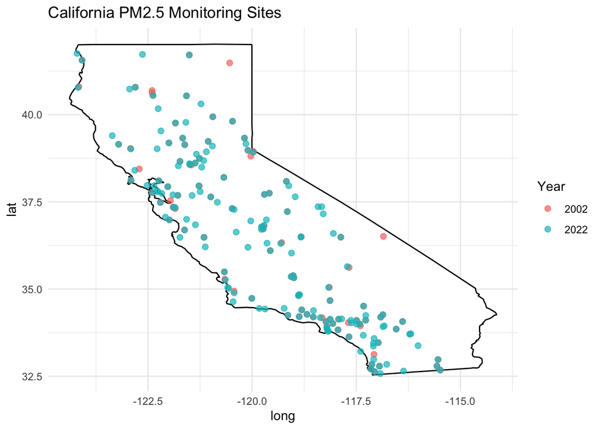

```r
PM_Combined <- PM_Combined |>
  mutate(year = lubridate::year(lubridate::mdy(Date)))


sites <- PM_Combined |>
  distinct(year, Site.Longitude, Site.Latitude)


california <- map_data("state") |>
  filter(region == "california")

ggplot() +
  geom_polygon(
    data = california,
    aes(x = long, y = lat, group = group),
    fill = "white",
    color = "black"
  ) +
  geom_point(
    data = sites,
    aes(
      x = Site.Longitude,
      y = Site.Latitude,
      color = factor(year)
    ),
    size = 2,
    alpha = 0.7
  ) +
  labs(
    title = "California PM2.5 Monitoring Sites",
    color = "Year"
  ) +
  theme_minimal ()
```

There are significantly more PM2.5 Monitoring Sites in 2022 compared to 2002

Part 4

```r
table(PM_Combined$year)
```

```
 2002  2022
15976 59918
```

```r
PM_summary <- PM_Combined |>
  group_by(year) |>
  summarize(
    missing = mean(is.na(PM25)) * 100,
    negative = mean(PM25 < 0, na.rm = TRUE) * 100
  )
```